# Model Seasonal ARIMA (SARIMA)

2024-10-22

## Packages

```r
library(tidyverse)
library(forecast)
library(TSA)
library(aTSA)
library(car)
library(lmtest)
```

## Pendahuluan

**Seasonal Autoregressive Integrated Moving Average (SARIMA)** merupakan pengembangan dari model Autoregressive Integrated Moving Average (ARIMA) pada data deret waktu yang memiliki pola musiman.

Model ARIMA musiman menggabungkan faktor-faktor non-musiman (regular) dan musiman dalam model multiplikasi, dengan notasi $ARIMA(p,d,q)×(P,D,Q)_s$ dengan:

- *p = non-seasonal AR order,*
- *d = non-seasonal differencing,*
- *q = non-seasonal MA order,*
- *P = seasonal AR order,*
- *D = seasonal differencing,*
- *Q = seasonal MA order,*
- *s = time span of repeating seasonal pattern.*

Tahapan identifikasi model SARIMA sama halnya seperti yang dilakukan pada model ARIMA regular atau model ARIMA non-seasonal, yaitu :

- Plot time series
- Identifikasi model
- Pendugaan parameter model
- Seleksi Model
- Melakukan peramalan menggunakan model terbaik

## Impor Data

```r
co2 <- datasets::co2
head(co2)
```

```
##         Jan    Feb    Mar    Apr    May    Jun
## 1959 315.42 316.31 316.50 317.56 318.13 318.00
```

```r
class(co2)
```

```
## [1] "ts"
```

## Eksplorasi Data

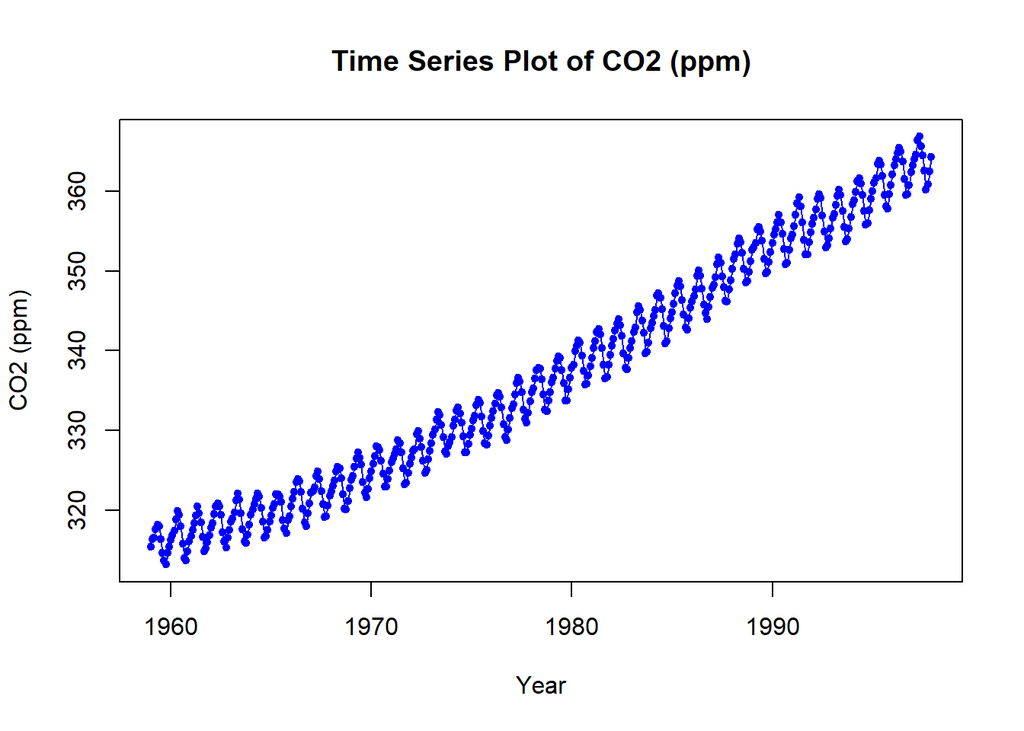

```r
ts.plot(co2, type="l", xlab = "Year", ylab="CO2 (ppm)", col="blue")
title(main = "Time Series Plot of CO2 (ppm)", cex.sub = 0.8)
points(co2, pch = 20, col = "blue")
```

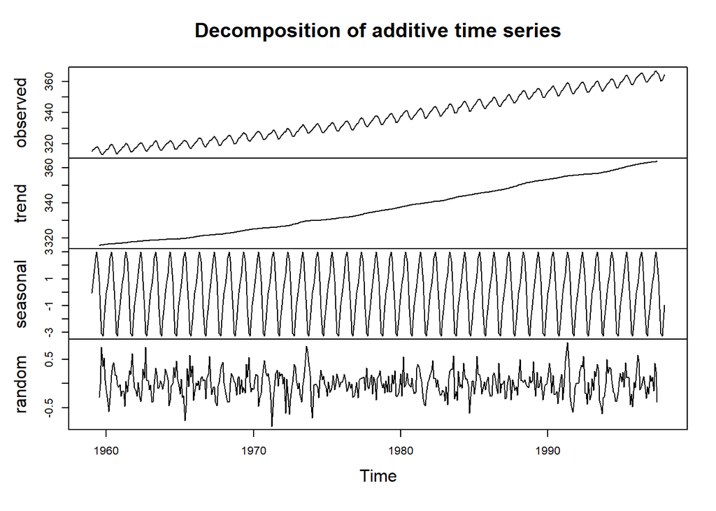

```r
dec.co2 <- decompose(co2)
plot(dec.co2)
```

Secara eksplorasi, terlihat adanya kecenderungan data memiliki tren naik dan perilaku berulang kecenderungan musiman) dalam deret tersebut. Kecenderungan musiman dapat dilihat dengan lebih jelas dengan menampilkan deret waktu per tahun.

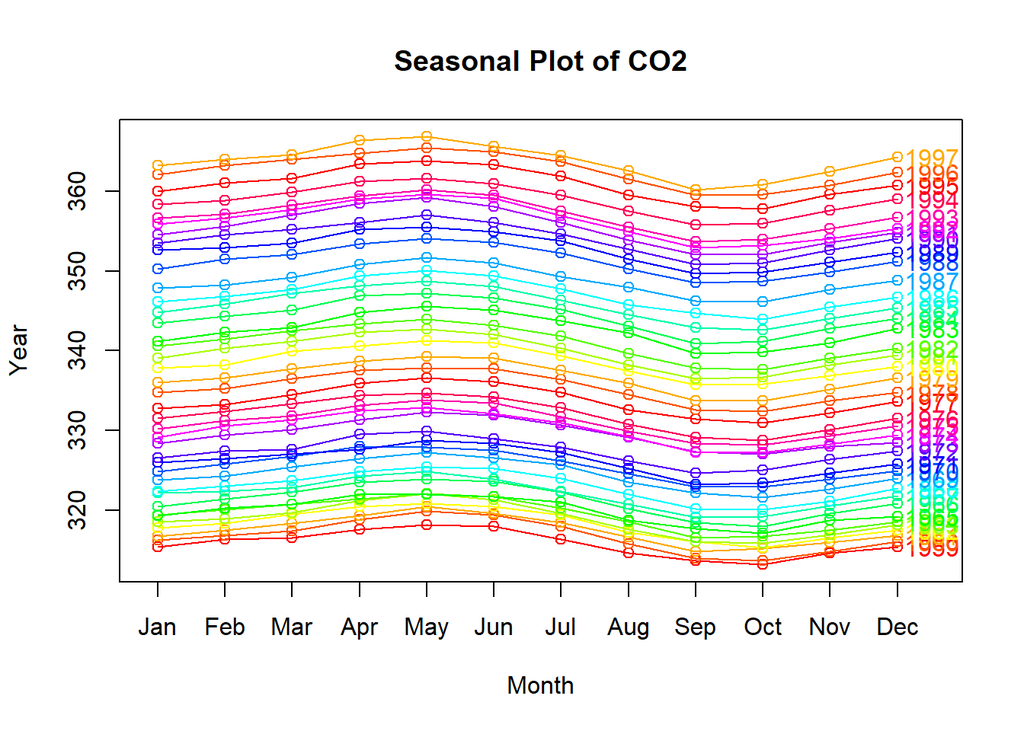

```r
seasonplot(co2,12,main="Seasonal Plot of CO2", ylab="Year",
           year.labels = TRUE, col=rainbow(18))
```

Gambar menunjukkan bahwa konsentrasi karbondioksida tinggi pada bulan Maret, April, Mei, Juni, Juli dan rendah pada bulan Agustus, September, Oktober, November. Perilaku tersebut terus berulang dari tahun ke tahun.

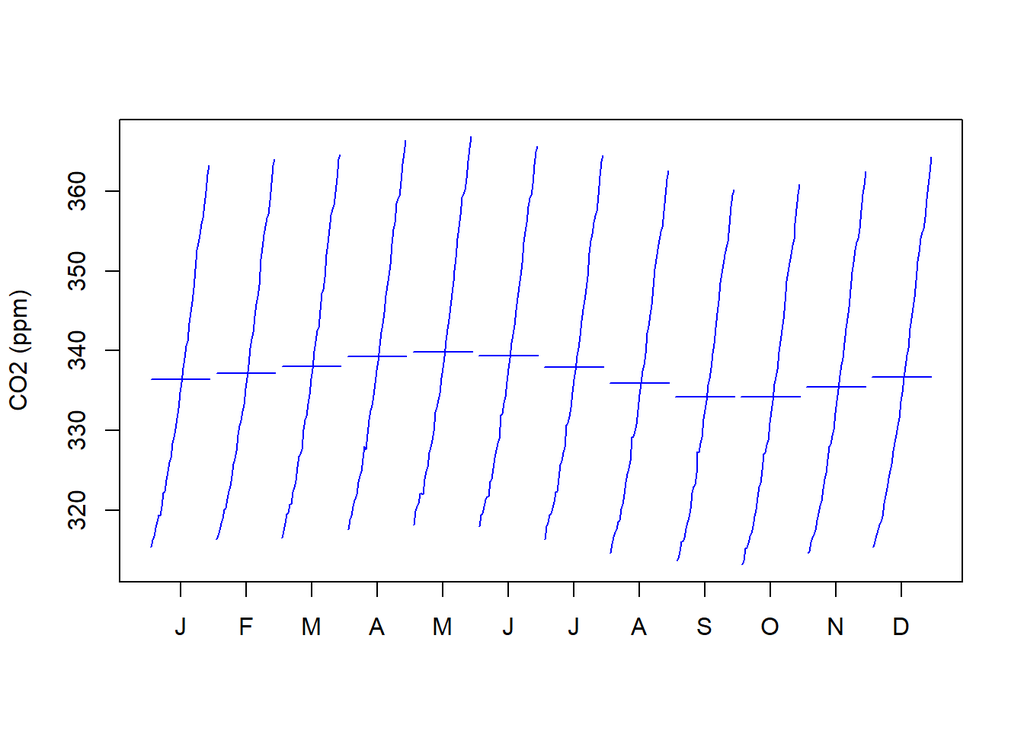

```r
monthplot(co2,ylab="CO2 (ppm)", col="blue")
```

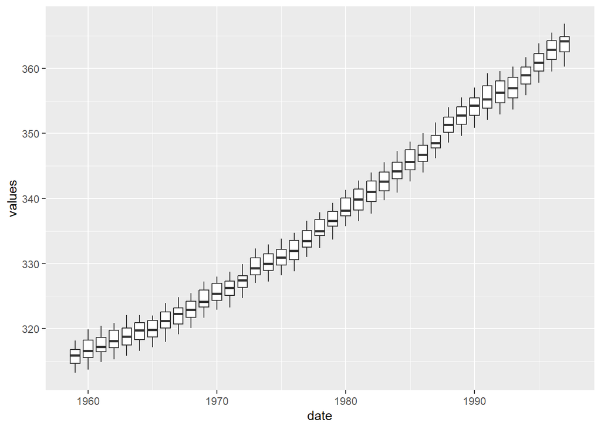

```r
frame<-data.frame(values=as.matrix(co2), date=lubridate::year(zoo::as.Date(co2)))

library(ggplot2)
ggplot(frame,aes(y=values,x=date,group=date))+
  geom_boxplot()
```

Berdasarkan hasil plot di atas dapat terlihat bahwa data memiliki pola yang hampir sama dari tahun ke tahun sehingga dapat disimpulkan bahwa periode musimannya adalah 12. Selain itu, apabila dilihat dari boxplot, terlihat bahwa data cenderung homogen dari tahun ke tahun. Untuk memastikan bahwa data homogen akan dilakukan uji homogenitas dengan `fligner.test`.

## Uji Homogenitas

Uji asumsi formal terhadap kehomogenan ragam yang digunakan yaitu *Fligner-Killen test*, dimana:

$H_0$ : Ragam homogen

$H_1$ : Ragam tidak homogen

```r
library(car)
fligner.test(values ~ date, data=frame)
```

```
##
##  Fligner-Killeen test of homogeneity of variances
##
## data:  values by date
## Fligner-Killeen:med chi-squared = 17.173, df = 38, p-value = 0.9985
```

Berdasarkan hasil uji *Fligner-Killeen* dengan menggunakan taraf signifikansi $\alpha=5\%$ didapatkan *p-value* sebesar 0.9985. $p-value=0.9885>\alpha=0.05$ sehingga tak tolak $H_0$ atau dengan kata lain **ragam data sudah stasioner**.

## Pembagian Data

Pembagian data dilakukan dengan mengambil sekitar 80% data awal (372 observasi) sebagai data latih dan 20% sisanya (96 observasi) sebagai data uji.

```r
train.ts <- subset(co2,start=1,end=372)
test.ts <- subset(co2,start=373,end=468)
```

### Plot Data Latih

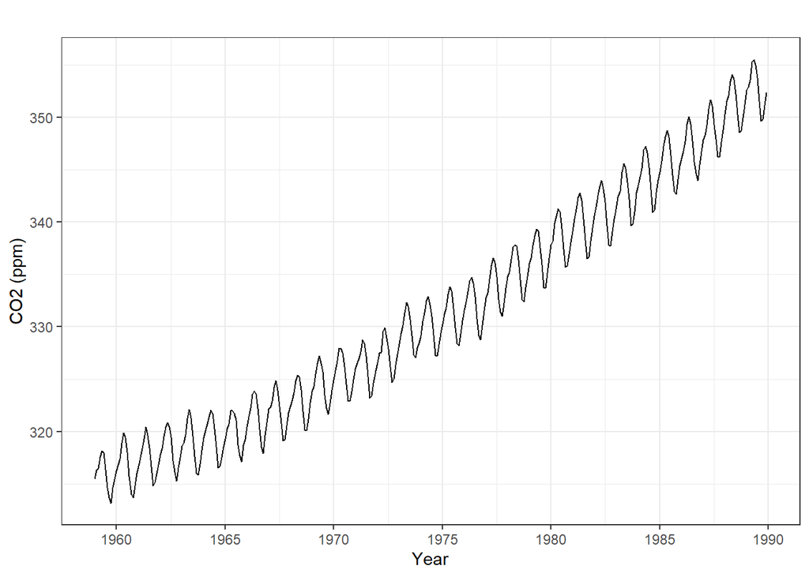

```r
autoplot(train.ts) + theme_bw() + xlab("Year") + ylab("CO2 (ppm)")
```

### Plot Data Uji

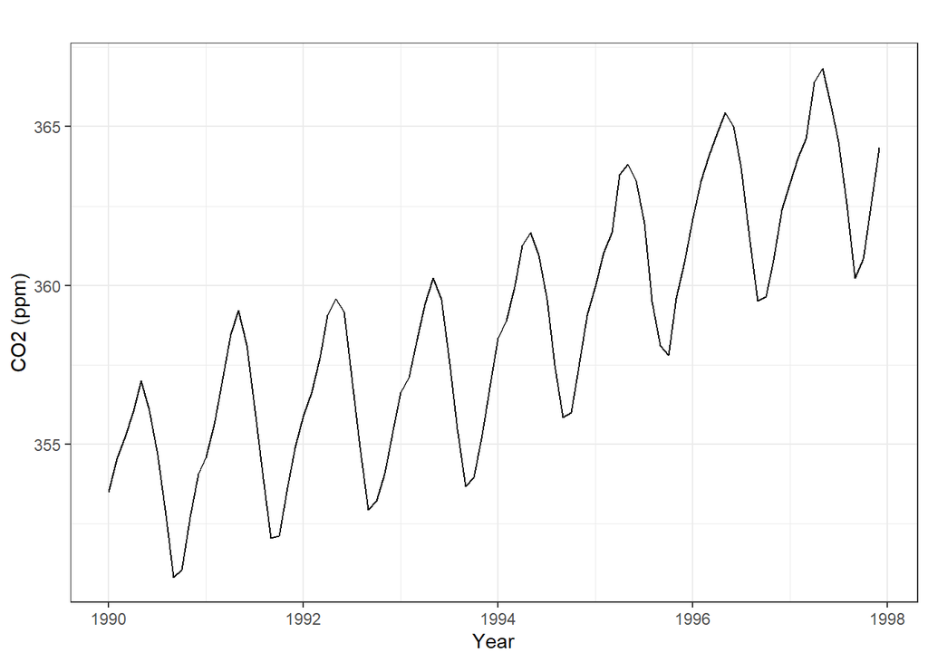

```r
autoplot(test.ts) + theme_bw() + xlab("Year") + ylab("CO2 (ppm)")
```

## Non-Seasonal ARIMA

### Kestasioneran Data

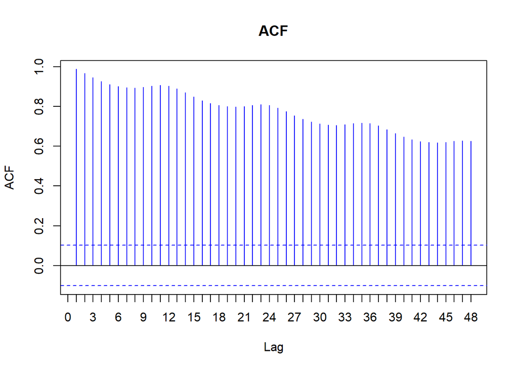

```r
acf0 <- acf(train.ts,main="ACF",lag.max=48,xaxt="n", col="blue")
axis(1, at=0:48/12, labels=0:48)
```

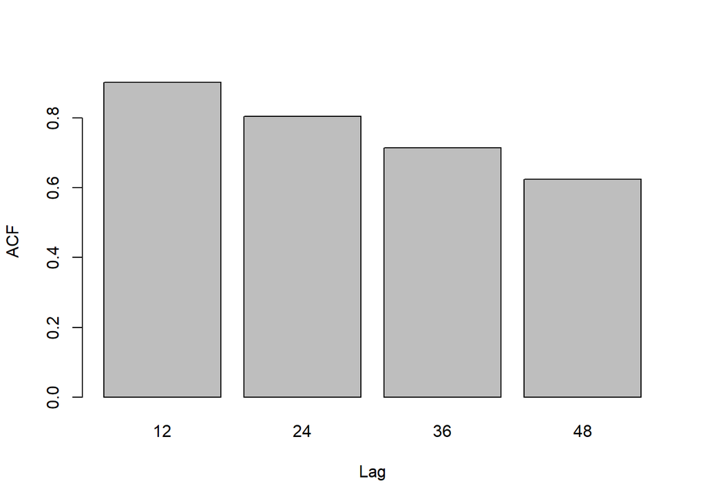

```r
acf0$lag <- acf0$lag * 12
acf0.1 <- as.data.frame(cbind(acf0$acf,acf0$lag))
acf0.2 <- acf0.1[which(acf0.1$V2%%12==0),]
barplot(height = acf0.2$V1,
names.arg=acf0.2$V2, ylab="ACF", xlab="Lag")
```

Berdasarkan plot deret sebelumnya diketahui bahwa perilaku deret berulang setiap tahun, atau dikatakan bahwa deret memiliki periode musiman bulanan, sehingga $s=12$. Perhatikan nilai fungsi autokorelasi pada lag-lag musiman (lag 12, 24, 36,...) dalam plot ACF contoh di atas. Tampak bahwa nilai autokorelasi pada lag-lag tersebut memiliki hubungan yang kuat. Bagaimanapun juga, plot ACF contoh meluruh secara perlahan dan membentuk pola gelombang kosinus teredam, yang menandakan ketidakstasioneran (plot deret juga menunjukkan adanya trend naik dalam deret).

```r
tseries::adf.test(train.ts)
```

```
##
##  Augmented Dickey-Fuller Test
##
## data:  train.ts
## Dickey-Fuller = -2.423, Lag order = 7, p-value = 0.3985
## alternative hypothesis: stationary
```

$H_0$ : Data tidak stasioner dalam rataan

$H_1$ : Data stasioner dalam rataan

Berdasarkan uji ADF tersebut, didapat *p-value* sebesar 0.3985 yang lebih besar dari taraf nyata 5% sehingga tak tolak $H_0$ dan menandakan bahwa data tidak stasioner dalam rataan. Hal ini sesuai dengan hasil eksplorasi menggunakan plot time series dan plot ACF, sehingga ketidakstasioneran model kedepannya harus ditangani.

### Pembedaan

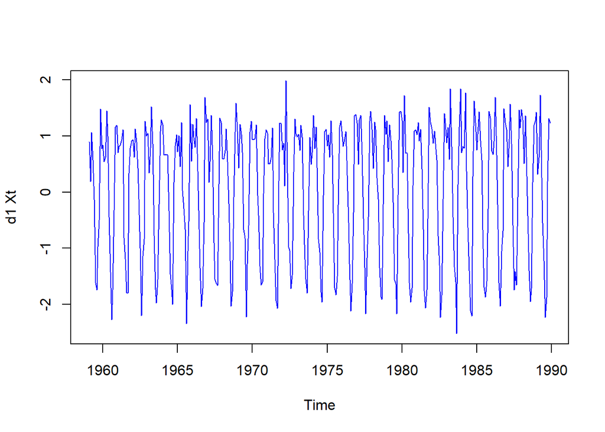

```r
d1 <- diff(train.ts)
ts.plot(d1, type="l", ylab="d1 Xt", col="blue")
```

*Differencing non-seasonal* $d=1$ jika dilihat berdasarkan plot di atas berhasil mengatasi ketidakstasioneran dalam rataan untuk komponen *non-seasonal*.

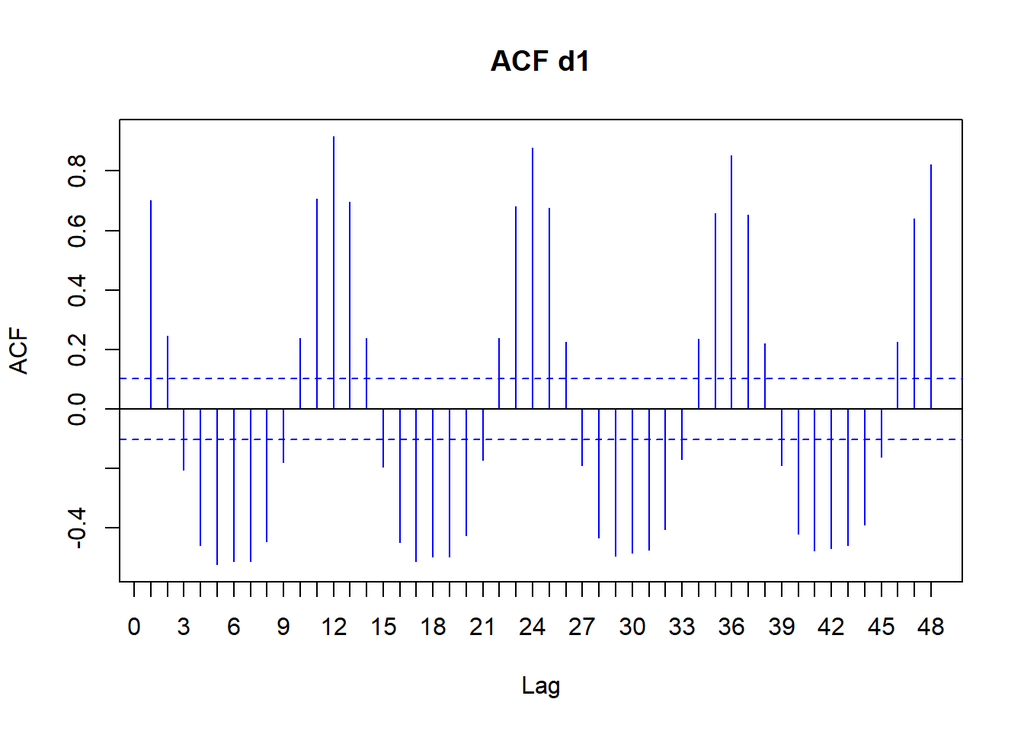

```r
acf1 <- acf(d1,lag.max=48,xaxt="n", main="ACF d1", col="blue")
axis(1, at=0:48/12, labels=0:48)
```

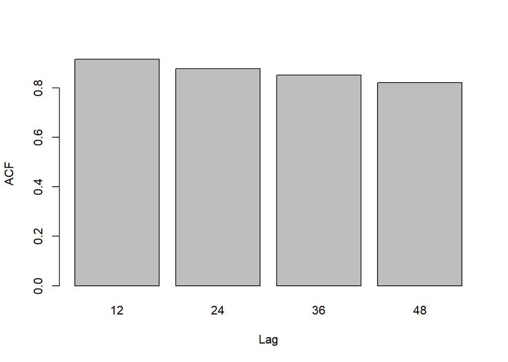

```r
acf2 <- acf1$lag <- acf1$lag * 12
acf1.1 <- as.data.frame(cbind(acf1$acf,acf1$lag))
acf1.2 <- acf1.1[which(acf1.1$V2%%12==0),]
barplot(height = acf1.2$V1, names.arg=acf1.2$V2, ylab="ACF", xlab="Lag")
```

Plot ACF data *non-seasonal differencing* $d=1$ mengkonfirmasi kestasioneran komponen *non-seasonal* (namun perhatikan lag 12,24, dst), pada *series* *seasonal* **belum stasioner**. Hal ini menunjukkan adanya kecenderungan musiman

## Seasonal ARIMA

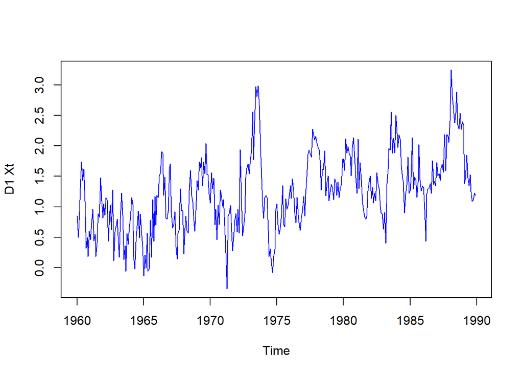

```r
D1 <- diff(train.ts,12)
ts.plot(D1, type="l", ylab="D1 Xt", col="blue")
```

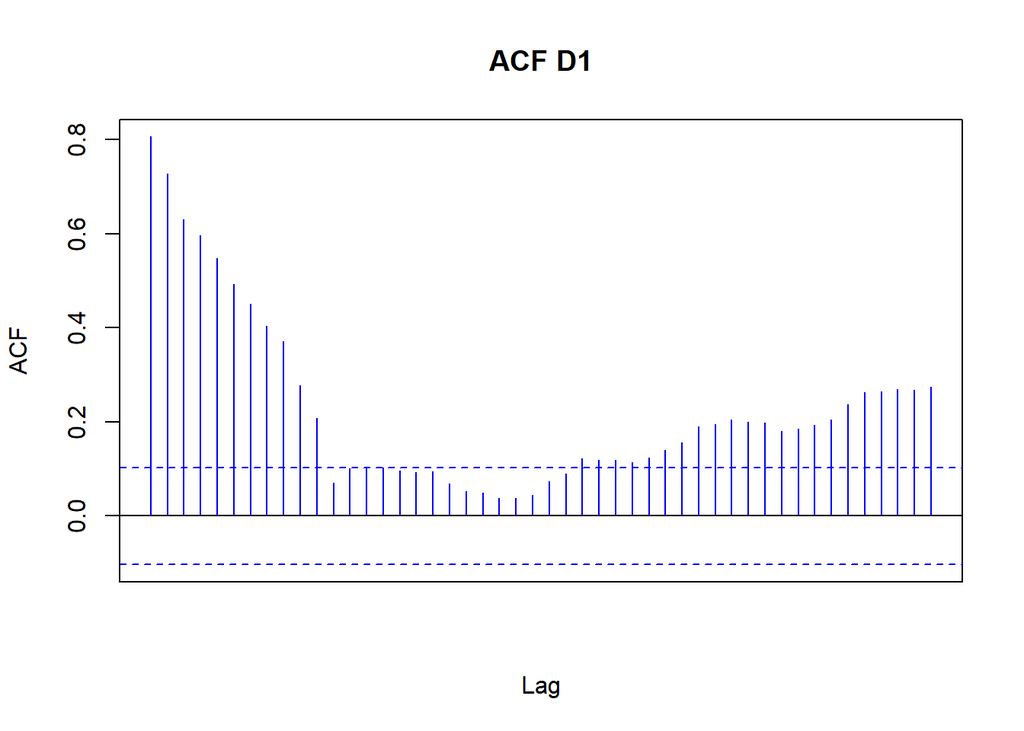

```r
acf2<-acf(D1,lag.max=48,xaxt="n", main="ACF D1", col="blue")
```

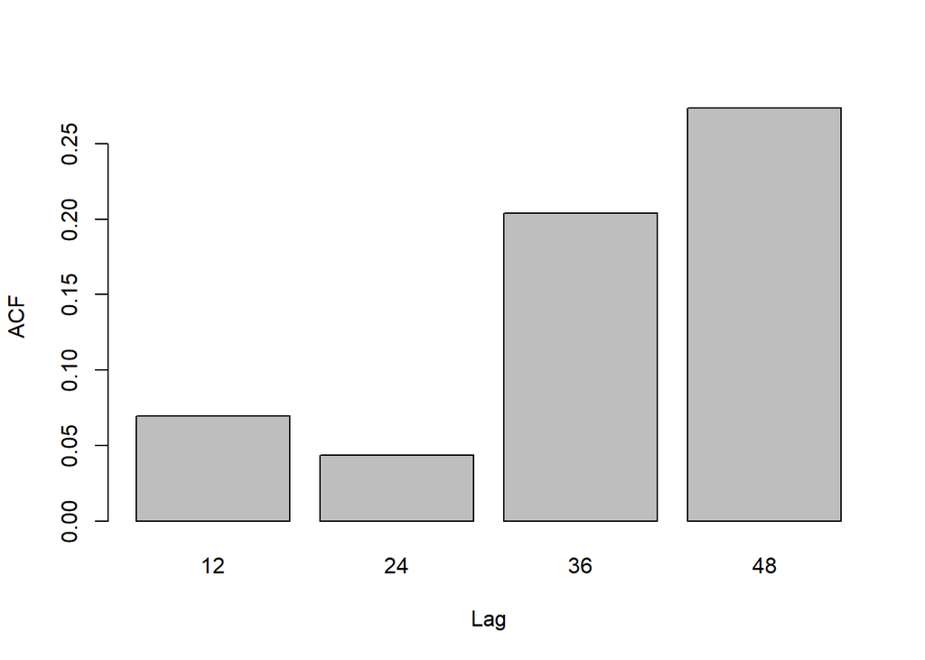

```r
acf2$lag <- acf2$lag * 12
acf2.1 <- as.data.frame(cbind(acf2$acf,acf2$lag))
acf2.2 <- acf2.1[which(acf2.1$V2%%12==0),]
barplot(height = acf2.2$V1, names.arg=acf2.2$V2, ylab="ACF", xlab="Lag")
```

Untuk menghilangkan kecenderungan musiman dilakukan pembedaan musiman terhadap deret hasil pembedaan pertama.

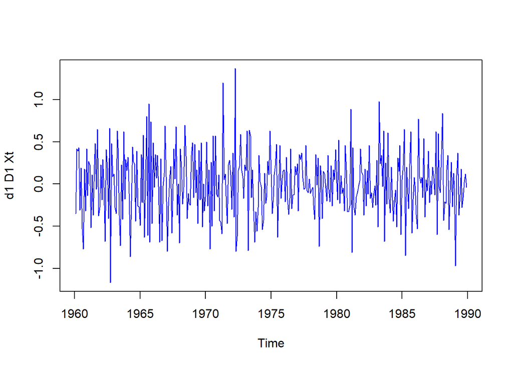

```r
d1D1 <- diff(D1)
ts.plot(d1D1, type="l", ylab="d1 D1 Xt", col="blue")
```

Setelah pembedaan pertama dan pembedaan musiman tampak bahwa deret sudah tidak memiliki kecenderungan apapun. Selanjutnya penentuan ordo *p*, *q* dan *P*, *Q* dapat dilakukan menggunakan plot ACF dan PACF contoh dari deret hasil pembedaan pertama dan pembedaan musiman tersebut.

### Identifikasi Model

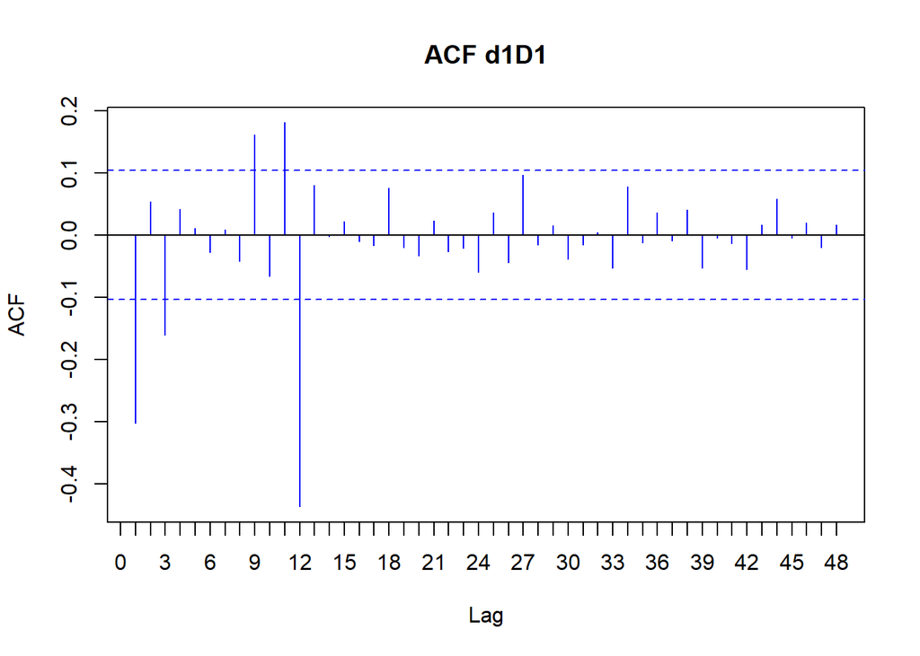

```r
acf3 <- acf(d1D1,lag.max=48,xaxt="n", main="ACF d1D1", col="blue")
axis(1, at=0:48/12, labels=0:48)
```

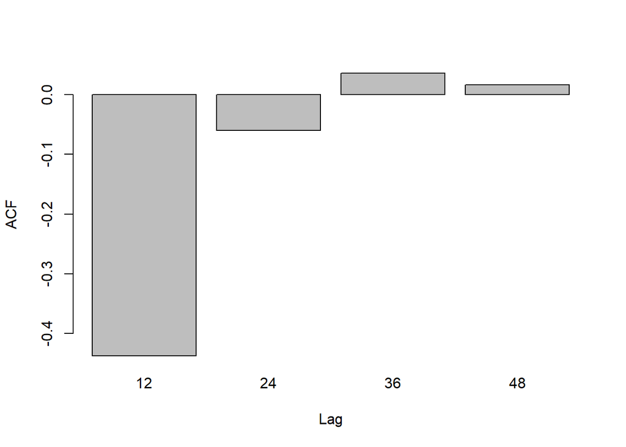

```r
acf3$lag <- acf3$lag * 12
acf3.1 <- as.data.frame(cbind(acf3$acf,acf3$lag))
acf3.2 <- acf3.1[which(acf3.1$V2%%12==0),]
barplot(height = acf3.2$V1, names.arg=acf3.2$V2, ylab="ACF",
xlab="Lag")
```

Berdasarkan plot ACF contoh lag 1 signifikan sehingga dipilih ordo *q*=1 , dan lag 12 adalah satu-satunya lag musiman yang signifikan sehingga order *Q*=1.

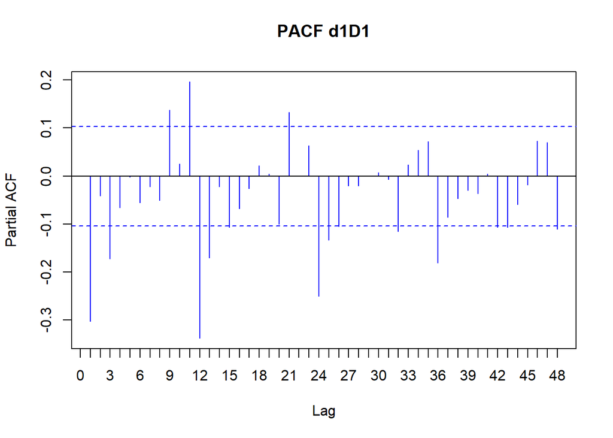

```r
pacf3 <- pacf(d1D1,lag.max=48,xaxt="n", main="PACF d1D1", col="blue")
axis(1, at=0:48/12, labels=0:48)
```

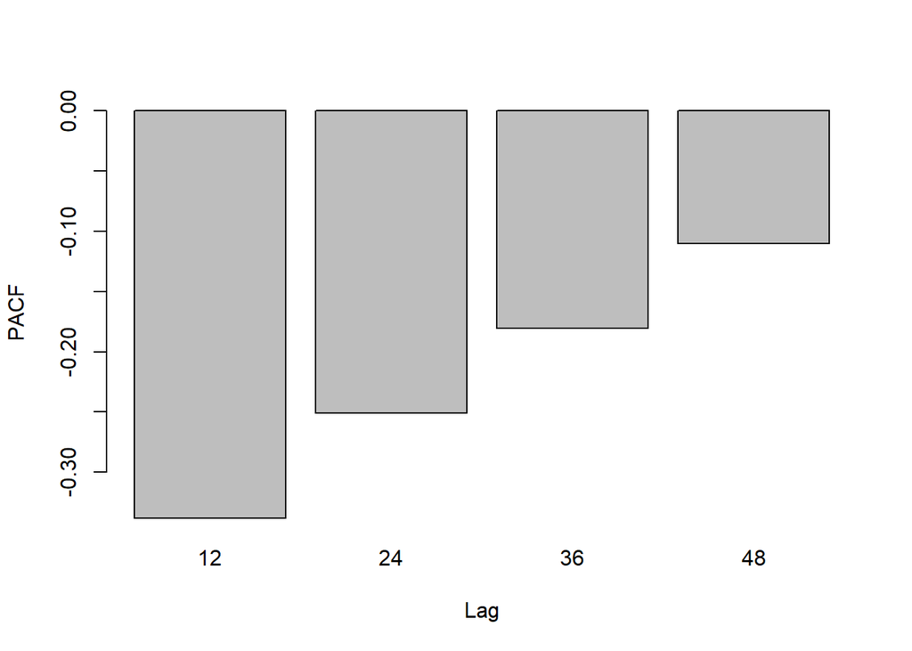

```r
pacf3$lag <- pacf3$lag * 12
pacf3.1 <- as.data.frame(cbind(pacf3$acf,pacf3$lag))
pacf3.2 <- pacf3.1[which(pacf3.1$V2%%12==0),]
barplot(height = pacf3.2$V1, names.arg=pacf3.2$V2, ylab="PACF", xlab="Lag")
```

Plot PACF contoh menunjukkan *cuts-off* pada lag-1 sehingga ordo *p*=1, sementara pada pola musimannya tidak terlihat model AR yang terbentuk karena cenderung *tails-off*.

Model musiman yang dipilih untuk deret konsentrasi karbon dioksida adalah $ARIMA(0,1,1)\times(0,1,1)_{12}$, $ARIMA(1,1,0)\times(0,1,1)_{12}$, $ARIMA(1,1,1)\times(0,1,1)_{12}$. Ingat kembali bahwa model yang digunakan bersifat tentatif dan dapat berubah saat diagnostik model.

**EACF**

```r
TSA::eacf(d1D1)
```

```
## AR/MA
##   0 1 2 3 4 5 6 7 8 9 10 11 12 13
## 0 x o x o o o o o x o x  x  o  o
## 1 x o x o o o o o x o o  x  o  o
## 2 x x x o o o o o o o o  x  x  x
## 3 x x x o o o o o o o o  x  x  x
## 4 o x x o o o o o o o o  x  x  o
## 5 o x o o o o o o o o o  x  x  o
## 6 x x o x o o o o o o o  x  o  x
## 7 x x x o o o o o o o o  x  o  x
```

Karena, kedua komponen telah stasioner. Identifikasi komponen *non-seasonal* adalah ARIMA(0,1,3), ARIMA(1,1,3). Identifikasi komponen *seasonal* adalah $ARIMA(0,1,1)_{12}$, sehingga model tentatif yang diperoleh adalah:

- $ARIMA(0,1,1)\times(0,1,1)_{12}$
- $ARIMA(1,1,0)\times(0,1,1)_{12}$
- $ARIMA(1,1,1)\times(0,1,1)_{12}$
- $ARIMA(0,1,3)\times(0,1,1)_{12}$
- $ARIMA(1,1,3)\times(0,1,1)_{12}$

### Pendugaan Parameter

```r
#ARIMA(0,1,1)x(0,1,1)12
tmodel1 <- Arima(train.ts,order=c(0,1,1),seasonal=c(0,1,1))
summary(tmodel1)
```

```
## Series: train.ts
## ARIMA(0,1,1)(0,1,1)[12]
##
## Coefficients:
##           ma1     sma1
##       -0.3615  -0.8610
## s.e.   0.0552   0.0324
##
## sigma^2 = 0.08454:  log likelihood = -65.29
## AIC=136.57   AICc=136.64   BIC=148.22
##
## Training set error measures:
##                      ME      RMSE       MAE         MPE       MAPE      MASE
## Training set 0.02084809 0.2848373 0.2263738 0.006106532 0.06841425 0.1832904
##                    ACF1
## Training set 0.02690203
```

```r
lmtest::coeftest(tmodel1)
```

```
##
## z test of coefficients:
##
##       Estimate Std. Error  z value  Pr(>|z|)
## ma1  -0.361496   0.055225  -6.5459 5.915e-11 ***
## sma1 -0.861014   0.032440 -26.5420 < 2.2e-16 ***
## ---
## Signif. codes:  0 '***' 0.001 '**' 0.01 '*' 0.05 '.' 0.1 ' ' 1
```

```r
#ARIMA(1,1,0)x(0,1,1)12
tmodel2 <- Arima(train.ts,order=c(1,1,0),seasonal=c(0,1,1))
summary(tmodel2)
```

```
## Series: train.ts
## ARIMA(1,1,0)(0,1,1)[12]
##
## Coefficients:
##           ar1     sma1
##       -0.3013  -0.8733
## s.e.   0.0508   0.0326
##
## sigma^2 = 0.08551:  log likelihood = -67.91
## AIC=141.82   AICc=141.89   BIC=153.47
##
## Training set error measures:
##                      ME      RMSE       MAE         MPE       MAPE      MASE
## Training set 0.01835178 0.2864616 0.2268146 0.005377399 0.06852447 0.1836472
##                    ACF1
## Training set -0.0114889
```

```r
lmtest::coeftest(tmodel2)
```

```
##
## z test of coefficients:
##
##       Estimate Std. Error  z value  Pr(>|z|)
## ar1  -0.301303   0.050751  -5.9369 2.904e-09 ***
## sma1 -0.873301   0.032638 -26.7574 < 2.2e-16 ***
## ---
## Signif. codes:  0 '***' 0.001 '**' 0.01 '*' 0.05 '.' 0.1 ' ' 1
```

```r
#ARIMA(1,1,1)x(0,1,1)12
tmodel3 <- Arima(train.ts,order=c(1,1,1),seasonal=c(0,1,1))
summary(tmodel3)
```

```
## Series: train.ts
## ARIMA(1,1,1)(0,1,1)[12]
##
## Coefficients:
##          ar1      ma1     sma1
##       0.2249  -0.5676  -0.8590
## s.e.  0.1544   0.1339   0.0322
##
## sigma^2 = 0.08445:  log likelihood = -64.48
## AIC=136.97   AICc=137.08   BIC=152.5
##
## Training set error measures:
##                      ME      RMSE       MAE         MPE       MAPE      MASE
## Training set 0.02338157 0.2842762 0.2262878 0.006843452 0.06838954 0.1832207
##                      ACF1
## Training set -0.001296546
```

```r
lmtest::coeftest(tmodel3)
```

```
##
## z test of coefficients:
##
##       Estimate Std. Error  z value  Pr(>|z|)
## ar1   0.224885   0.154356   1.4569    0.1451
## ma1  -0.567646   0.133947  -4.2378 2.257e-05 ***
## sma1 -0.859013   0.032171 -26.7015 < 2.2e-16 ***
## ---
## Signif. codes:  0 '***' 0.001 '**' 0.01 '*' 0.05 '.' 0.1 ' ' 1
```

```r
#ARIMA(0,1,3)x(0,1,1)12
tmodel4 <- Arima(train.ts,order=c(0,1,3),seasonal=c(0,1,1))
summary(tmodel4)
```

```
## Series: train.ts
## ARIMA(0,1,3)(0,1,1)[12]
##
## Coefficients:
##           ma1      ma2      ma3     sma1
##       -0.3504  -0.0161  -0.0967  -0.8597
## s.e.   0.0533   0.0559   0.0519   0.0325
##
## sigma^2 = 0.08407:  log likelihood = -63.16
## AIC=136.32   AICc=136.49   BIC=155.74
##
## Training set error measures:
##                      ME      RMSE       MAE        MPE       MAPE      MASE
## Training set 0.02431332 0.2832465 0.2244853 0.00711694 0.06781885 0.1817613
##                     ACF1
## Training set 0.008491678
```

```r
lmtest::coeftest(tmodel4)
```

```
##
## z test of coefficients:
##
##       Estimate Std. Error  z value  Pr(>|z|)
## ma1  -0.350378   0.053307  -6.5729 4.935e-11 ***
## ma2  -0.016086   0.055888  -0.2878   0.77349
## ma3  -0.096680   0.051898  -1.8629   0.06248 .
## sma1 -0.859717   0.032535 -26.4244 < 2.2e-16 ***
## ---
## Signif. codes:  0 '***' 0.001 '**' 0.01 '*' 0.05 '.' 0.1 ' ' 1
```

```r
#ARIMA(1,1,3)x(0,1,1)12
tmodel5 <- Arima(train.ts,order=c(1,1,3),seasonal=c(0,1,1))
summary(tmodel5)
```

```
## Series: train.ts
## ARIMA(1,1,3)(0,1,1)[12]
##
## Coefficients:
##          ar1      ma1      ma2      ma3     sma1
##       0.0429  -0.3928  -0.0009  -0.0945  -0.8598
## s.e.  0.5783   0.5757   0.2119   0.0610   0.0326
##
## sigma^2 = 0.0843:  log likelihood = -63.16
## AIC=138.32   AICc=138.55   BIC=161.62
##
## Training set error measures:
##                      ME      RMSE       MAE         MPE       MAPE      MASE
## Training set 0.02443058 0.2832414 0.2244944 0.007151444 0.06782137 0.1817687
##                     ACF1
## Training set 0.007974197
```

```r
lmtest::coeftest(tmodel5)
```

```
##
## z test of coefficients:
##
##         Estimate  Std. Error  z value Pr(>|z|)
## ar1   0.04285387  0.57834849   0.0741   0.9409
## ma1  -0.39280462  0.57572329  -0.6823   0.4951
## ma2  -0.00090971  0.21185836  -0.0043   0.9966
## ma3  -0.09454751  0.06102460  -1.5493   0.1213
## sma1 -0.85982225  0.03260358 -26.3720   <2e-16 ***
## ---
## Signif. codes:  0 '***' 0.001 '**' 0.01 '*' 0.05 '.' 0.1 ' ' 1
```

```r
AICKandidatModel <- c(tmodel1$aic, tmodel2$aic, tmodel3$aic,
                      tmodel4$aic, tmodel5$aic)
AICcKandidatModel <- c(tmodel1$aicc, tmodel2$aicc, tmodel3$aicc,
                       tmodel4$aicc, tmodel5$aicc)
BICKandidatModel <- c(tmodel1$bic, tmodel2$bic, tmodel3$bic,
                      tmodel4$bic, tmodel5$bic)
KandidatModelARIMA <- c("ARIMA(0,1,1)(0,1,1)12", "ARIMA(1,1,0)(0,1,1)12",
                        "ARIMA(1,1,1)(0,1,1)12", "ARIMA(0,1,3)(0,1,1)12",
                        "ARIMA(1,1,3)(0,1,1)12")
compmodelARIMA <- cbind(KandidatModelARIMA, AICKandidatModel,
                        AICcKandidatModel, BICKandidatModel)
colnames(compmodelARIMA) <- c("Kandidat Model", "Nilai AIC",
                              "Nilai AICc", "Nilai BIC")
compmodelARIMA <- as.data.frame(compmodelARIMA)
compmodelARIMA
```

```
##          Kandidat Model        Nilai AIC       Nilai AICc        Nilai BIC
## 1 ARIMA(0,1,1)(0,1,1)12 136.574804108557  136.64240974236 148.224771274022
## 2 ARIMA(1,1,0)(0,1,1)12 141.824197586635 141.891803220438   153.4741647521
## 3 ARIMA(1,1,1)(0,1,1)12 136.966769525023 137.079763875305 152.500059078976
## 4 ARIMA(0,1,3)(0,1,1)12 136.319911328034 136.489882999422 155.736523270476
## 5 ARIMA(1,1,3)(0,1,1)12 138.315662122986 138.554298486622 161.615596453916
```

Model **terbaik** berdasarkan nilai **AIC dan AICc terkecil** dari kandidat model **yaitu** $ARIMA(0,1,3)\times(0,1,1)_{12}$, tetapi dengan mempertimbangkan signifikansi parameter dan kesederhanaan model akan dipilih $ARIMA(0,1,1)\times(0,1,1)_{12}$

```r
model.auto.arima <- auto.arima(train.ts)
summary(model.auto.arima)
```

```
## Series: train.ts
## ARIMA(0,1,1)(2,1,2)[12]
##
## Coefficients:
##           ma1     sar1     sar2     sma1     sma2
##       -0.3671  -0.2738  -0.0704  -0.5730  -0.2312
## s.e.   0.0561   0.6909   0.0691   0.6911   0.6027
##
## sigma^2 = 0.0849:  log likelihood = -64.5
## AIC=141   AICc=141.24   BIC=164.3
##
## Training set error measures:
##                     ME      RMSE       MAE         MPE       MAPE      MASE
## Training set 0.0206181 0.2842421 0.2265058 0.006039662 0.06844498 0.1833972
##                    ACF1
## Training set 0.02806049
```

```r
lmtest::coeftest(model.auto.arima)
```

```
##
## z test of coefficients:
##
##       Estimate Std. Error z value  Pr(>|z|)
## ma1  -0.367091   0.056124 -6.5407 6.125e-11 ***
## sar1 -0.273800   0.690936 -0.3963    0.6919
## sar2 -0.070434   0.069114 -1.0191    0.3082
## sma1 -0.573038   0.691124 -0.8291    0.4070
## sma2 -0.231228   0.602735 -0.3836    0.7013
## ---
## Signif. codes:  0 '***' 0.001 '**' 0.01 '*' 0.05 '.' 0.1 ' ' 1
```

### Diagnostik Model

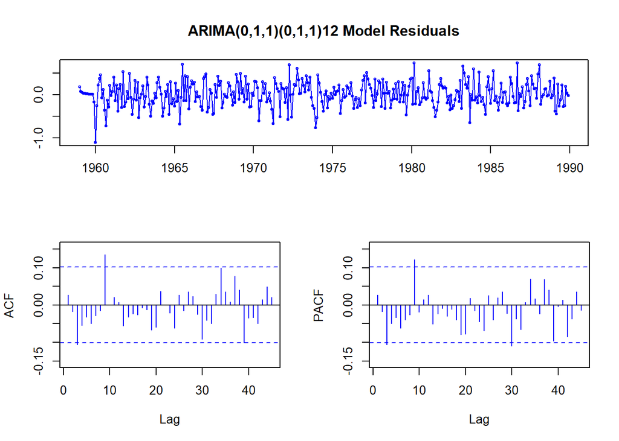

```r
tsdisplay(residuals(tmodel1), lag.max=45,
          main='ARIMA(0,1,1)(0,1,1)12 Model Residuals', col="blue")
```

```r
#Eksplorasi
sisaan.model1 <- tmodel1$residuals
par(mfrow=c(2,2))
car::qqPlot(sisaan.model1)
```

```
## [1]  13 180
```

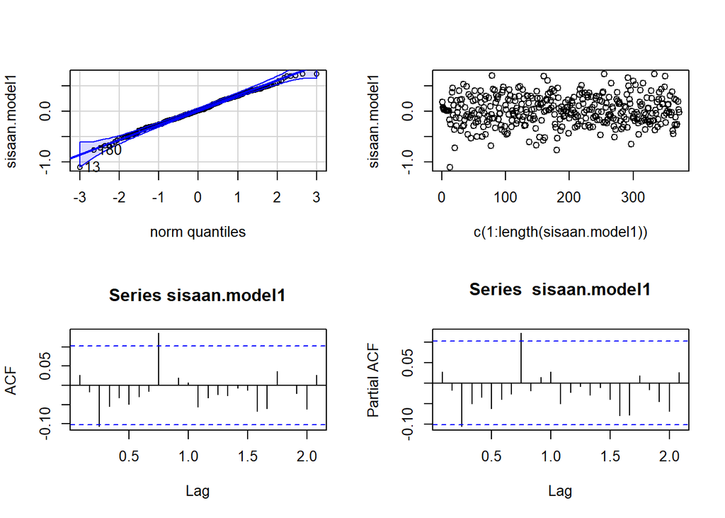

```r
plot(c(1:length(sisaan.model1)),sisaan.model1)
acf(sisaan.model1)
pacf(sisaan.model1)
```

```r
par(mfrow = c(1,1))
```

Berdasarkan plot di atas terlihat bahwa sisaan mengikuti sebaran normal. Selanjutnya, ditinjau dari plot ACF dan PACF terlihat bahwa ada lag yang signifikan. Hal tersebut menunjukkan bahwa kemungkinan ada gejala autokorelasi pada sisaan. Selanjutnya, untuk memastikan kembali akan dilakukan uji asumsi secara formal:

#### Uji Formal

```r
#1) Sisaan Menyebar Normal
ks.test(sisaan.model1,"pnorm")
```

```
##
##  Asymptotic one-sample Kolmogorov-Smirnov test
##
## data:  sisaan.model1
## D = 0.28741, p-value < 2.2e-16
## alternative hypothesis: two-sided
```

```r
#tak tolak H0 > sisaan menyebar normal
shapiro.test(sisaan.model1)
```

```
##
##  Shapiro-Wilk normality test
##
## data:  sisaan.model1
## W = 0.99528, p-value = 0.3206
```

```r
nortest::ad.test(sisaan.model1)
```

```
##
##  Anderson-Darling normality test
##
## data:  sisaan.model1
## A = 0.2699, p-value = 0.6763
```

Selain dengan eksplorasi, asumsi tersebut dapat diuji menggunakan uji formal. Pada tahapan ini uji formal yang digunakan untuk normalitas adalah uji Kolmogorov-Smirnov (KS), Shapiro-Wilk, dan Anderson-Darling. Hipotesis pada uji kenormalan adalah sebagai berikut.

$H_0$ : Sisaan menyebar normal

$H_1$ : Sisaan tidak menyebar normal

```r
#2) Sisaan saling bebas/tidak ada autokorelasi
Box.test(sisaan.model1, type = "Ljung")
```

```
##
##  Box-Ljung test
##
## data:  sisaan.model1
## X-squared = 0.2714, df = 1, p-value = 0.6024
```

```r
#tak tolak H0 > sisaan saling bebas
```

Selanjutnya akan dilakukan uji formal untuk kebebasan sisaan menggunakan uji Ljung-Box. Hipotesis yang digunakan adalah sebagai berikut.

$H_0$ : Sisaan saling bebas

$H_1$ : Sisaan tidak tidak saling bebas

Berdasarkan uji Ljung-Box tersebut, didapat *p-value* sebesar 0.6024 yang lebih besar dari taraf nyata 5% sehingga tak tolak $H_0$ dan menandakan bahwa sisaan saling bebas. Hal ini berbeda dengan eksplorasi.

```r
#3) Sisaan homogen
Box.test((sisaan.model1)^2, type = "Ljung")
```

```
##
##  Box-Ljung test
##
## data:  (sisaan.model1)^2
## X-squared = 0.25301, df = 1, p-value = 0.615
```

```r
#tak tolak H0 > sisaan homogen
```

Hipotesis yang digunakan untuk uji kehomogenan ragam adalah sebagai berikut.

$H_0$ : Ragam sisaan homogen

$H_1$ : Ragam sisaan tidak homogen

Berdasarkan uji Ljung-Box terhadap sisaan kuadrat tersebut, didapat *p-value* sebesar 0.615 yang lebih besar dari taraf nyata 5% sehingga tak tolak $H_0$ dan menandakan bahwa ragam sisaan homogen.

```r
#4) Nilai tengah sisaan sama dengan nol
t.test(sisaan.model1, mu = 0, conf.level = 0.95)
```

```
##
##  One Sample t-test
##
## data:  sisaan.model1
## t = 1.4136, df = 371, p-value = 0.1583
## alternative hypothesis: true mean is not equal to 0
## 95 percent confidence interval:
##  -0.00815276  0.04984894
## sample estimates:
##  mean of x
## 0.02084809
```

```r
#tak tolak h0 > nilai tengah sisaan sama dengan 0
```

Terakhir, dengan uji-t, akan dicek apakah nilai tengah sisaan sama dengan nol. Hipotesis yang diujikan sebagai berikut.

$H_0$ : nilai tengah sisaan sama dengan 0

$H_1$ : nilai tengah sisaan tidak sama dengan 0

Berdasarkan uji-ttersebut, didapat *p-value* sebesar 0.1583 yang lebih besar dari taraf nyata 5% sehingga tak tolak $H_0$ dan menandakan bahwa nilai tengah sisaan sama dengan nol. Hal ini berbeda dengan eksplorasi.

### Overfitting

Pertama, *overfit* pada model non-musimannya (p,q)

```r
#ARIMA(0,1,2)x(1,1,1)12
tmodel1.ofq <- Arima(train.ts,order=c(0,1,2),seasonal=c(0,1,1))
summary(tmodel1.ofq)
```

```
## Series: train.ts
## ARIMA(0,1,2)(0,1,1)[12]
##
## Coefficients:
##           ma1      ma2     sma1
##       -0.3545  -0.0486  -0.8591
## s.e.   0.0527   0.0527   0.0323
##
## sigma^2 = 0.08462:  log likelihood = -64.87
## AIC=137.73   AICc=137.85   BIC=153.27
##
## Training set error measures:
##                      ME      RMSE       MAE         MPE       MAPE      MASE
## Training set 0.02197765 0.2845692 0.2263238 0.006434397 0.06840669 0.1832499
##                   ACF1
## Training set 0.0141744
```

```r
lmtest::coeftest(tmodel1.ofq)
```

```
##
## z test of coefficients:
##
##       Estimate Std. Error  z value  Pr(>|z|)
## ma1  -0.354450   0.052745  -6.7201 1.816e-11 ***
## ma2  -0.048620   0.052739  -0.9219    0.3566
## sma1 -0.859137   0.032294 -26.6033 < 2.2e-16 ***
## ---
## Signif. codes:  0 '***' 0.001 '**' 0.01 '*' 0.05 '.' 0.1 ' ' 1
```

Pada model musiman, ordo yang dilakukan *overfit* adalah ordo musiman (*P*, *Q*).

```r
#ARIMA(0,1,1)x(1,1,1)12
tmodel1.ofP <- Arima(train.ts,order=c(0,1,1),seasonal=c(1,1,1))
summary(tmodel1.ofP)
```

```
## Series: train.ts
## ARIMA(0,1,1)(1,1,1)[12]
##
## Coefficients:
##           ma1    sar1     sma1
##       -0.3597  0.0162  -0.8655
## s.e.   0.0557  0.0623   0.0364
##
## sigma^2 = 0.08476:  log likelihood = -65.25
## AIC=138.51   AICc=138.62   BIC=154.04
##
## Training set error measures:
##                      ME   RMSE       MAE         MPE      MAPE      MASE
## Training set 0.02084024 0.2848 0.2263754 0.006103287 0.0684196 0.1832917
##                    ACF1
## Training set 0.02671043
```

```r
lmtest::coeftest(tmodel1.ofP)
```

```
##
## z test of coefficients:
##
##       Estimate Std. Error  z value  Pr(>|z|)
## ma1  -0.359677   0.055695  -6.4580 1.061e-10 ***
## sar1  0.016248   0.062333   0.2607    0.7943
## sma1 -0.865549   0.036397 -23.7809 < 2.2e-16 ***
## ---
## Signif. codes:  0 '***' 0.001 '**' 0.01 '*' 0.05 '.' 0.1 ' ' 1
```

```r
#ARIMA(0,1,1)x(0,1,2)12
tmodel1.ofQ <- Arima(train.ts,order=c(0,1,1),seasonal=c(0,1,2))
summary(tmodel1.ofQ)
```

```
## Series: train.ts
## ARIMA(0,1,1)(0,1,2)[12]
##
## Coefficients:
##           ma1     sma1     sma2
##       -0.3594  -0.8473  -0.0163
## s.e.   0.0557   0.0582   0.0580
##
## sigma^2 = 0.08475:  log likelihood = -65.25
## AIC=138.5   AICc=138.61   BIC=154.03
##
## Training set error measures:
##                      ME      RMSE       MAE        MPE     MAPE      MASE
## Training set 0.02083778 0.2847937 0.2263776 0.00610242 0.068421 0.1832934
##                    ACF1
## Training set 0.02668434
```

```r
lmtest::coeftest(tmodel1.ofQ)
```

```
##
## z test of coefficients:
##
##       Estimate Std. Error  z value  Pr(>|z|)
## ma1  -0.359409   0.055738  -6.4481 1.132e-10 ***
## sma1 -0.847342   0.058151 -14.5714 < 2.2e-16 ***
## sma2 -0.016326   0.057993  -0.2815    0.7783
## ---
## Signif. codes:  0 '***' 0.001 '**' 0.01 '*' 0.05 '.' 0.1 ' ' 1
```

Model *overfitting* yang dicobakan menghasilkan nilai AIC dan signifikansi parameter yang tidak lebih baik dari model awal. Oleh karena itu, model yang digunakan tetap model awal.

### Peramalan

```r
ramalan_sarima = forecast::forecast(tmodel1, 96)
ramalan_sarima
```

```
##          Point Forecast    Lo 80    Hi 80    Lo 95    Hi 95
## Jan 1990       353.4560 353.0833 353.8286 352.8861 354.0258
## Feb 1990       354.2238 353.7817 354.6659 353.5477 354.8999
## Mar 1990       355.0954 354.5934 355.5975 354.3276 355.8633
## Apr 1990       356.4755 355.9199 357.0310 355.6258 357.3252
## May 1990       357.0384 356.4340 357.6428 356.1141 357.9627
## Jun 1990       356.5024 355.8529 357.1519 355.5090 357.4958
## Jul 1990       355.0546 354.3629 355.7464 353.9967 356.1125
## Aug 1990       353.1269 352.3954 353.8585 352.0082 354.2457
## Sep 1990       351.3817 350.6125 352.1509 350.2053 352.5581
## Oct 1990       351.3244 350.5192 352.1296 350.0930 352.5558
## Nov 1990       352.6638 351.8242 353.5034 351.3798 353.9479
## Dec 1990       353.9201 353.0474 354.7927 352.5854 355.2547
## Jan 1991       355.0006 354.0811 355.9201 353.5944 356.4069
## Feb 1991       355.7685 354.8099 356.7271 354.3024 357.2345
## Mar 1991       356.6401 355.6439 357.6363 355.1166 358.1636
## Apr 1991       358.0201 356.9878 359.0525 356.4413 359.5990
## May 1991       358.5831 357.5157 359.6504 356.9507 360.2155
## Jun 1991       358.0471 356.9458 359.1483 356.3629 359.7312
## Jul 1991       356.5993 355.4652 357.7334 354.8649 358.3337
## Aug 1991       354.6716 353.5056 355.8376 352.8884 356.4549
## Sep 1991       352.9264 351.7293 354.1235 351.0956 354.7571
## Oct 1991       352.8691 351.6417 354.0964 350.9920 354.7462
## Nov 1991       354.2085 352.9516 355.4654 352.2862 356.1308
## Dec 1991       355.4647 354.1789 356.7506 353.4983 357.4312
## Jan 1992       356.5453 355.2196 357.8710 354.5178 358.5728
## Feb 1992       357.3132 355.9530 358.6733 355.2330 359.3933
## Mar 1992       358.1848 356.7911 359.5785 356.0533 360.3163
## Apr 1992       359.5648 358.1383 360.9913 357.3832 361.7465
## May 1992       360.1278 358.6692 361.5863 357.8971 362.3584
## Jun 1992       359.5917 358.1018 361.0816 357.3131 361.8703
## Jul 1992       358.1440 356.6234 359.6646 355.8184 360.4695
## Aug 1992       356.2163 354.6656 357.7670 353.8447 358.5879
## Sep 1992       354.4711 352.8908 356.0513 352.0543 356.8878
## Oct 1992       354.4137 352.8045 356.0230 351.9526 356.8749
## Nov 1992       355.7532 354.1155 357.3909 353.2485 358.2578
## Dec 1992       357.0094 355.3437 358.6751 354.4620 359.5569
## Jan 1993       358.0900 356.3867 359.7933 355.4850 360.6949
## Feb 1993       358.8578 357.1215 360.5942 356.2023 361.5133
## Mar 1993       359.7295 357.9607 361.4982 357.0244 362.4346
```

[output cut: 42 more lines]

```
## Oct 1996       360.5925 357.4783 363.7066 355.8297 365.3552
## Nov 1996       361.9319 358.7873 365.0765 357.1226 366.7412
## Dec 1996       363.1881 360.0134 366.3629 358.3328 368.0435
## Jan 1997       364.2687 361.0567 367.4807 359.3563 369.1811
## Feb 1997       365.0365 361.7904 368.2827 360.0720 370.0011
## Mar 1997       365.9082 362.6283 369.1881 360.8920 370.9244
## Apr 1997       367.2882 363.9749 370.6016 362.2209 372.3555
## May 1997       367.8511 364.5047 371.1976 362.7332 372.9691
## Jun 1997       367.3151 363.9359 370.6943 362.1471 372.4832
## Jul 1997       365.8674 362.4557 369.2790 360.6497 371.0850
## Aug 1997       363.9397 360.4959 367.3835 358.6729 369.2065
## Sep 1997       362.1944 358.7188 365.6701 356.8789 367.5100
## Oct 1997       362.1371 358.6299 365.6443 356.7733 367.5009
## Nov 1997       363.4766 359.9381 367.0150 358.0649 368.8882
## Dec 1997       364.7328 361.1633 368.3023 359.2738 370.1918
```

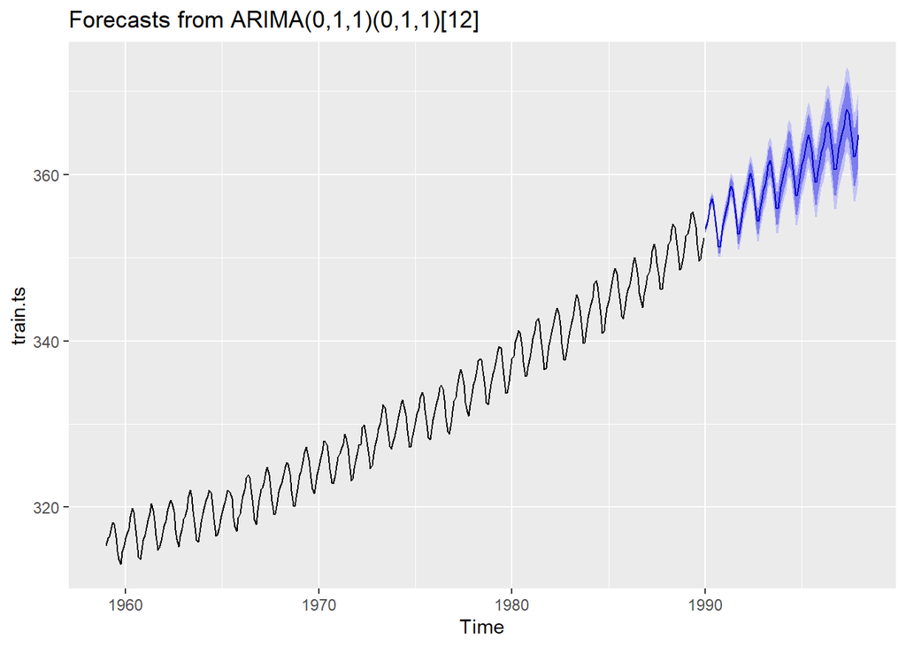

```r
autoplot(ramalan_sarima, col="blue")
```

```r
accuracy(ramalan_sarima,test.ts)
```

```
##                       ME      RMSE       MAE          MPE       MAPE      MASE
## Training set  0.02084809 0.2848373 0.2263738  0.006106532 0.06841425 0.1832904
## Test set     -0.95735049 1.1487183 1.0040280 -0.266792576 0.27986066 0.8129416
##                    ACF1 Theil's U
## Training set 0.02690203        NA
## Test set     0.86252432 0.8723514
```